# Simple document

Felix Song

I’m an R Markdown document!

# Section 0: Libraries

# Section 1

Here’s a **code chunk** that samples from a *normal distribution*:

```r
samp = rnorm(100)
length(samp)
```

```
## [1] 100
```

# Section 2

I can take the mean of the sample, too! The mean is 0.1548401.

# Section 3

```r
plot_df =
    tibble(
        x = rnorm(1000, sd = 0.5),
        y = 1 + 2*x + rnorm(1000)
    )
```

# Section 4: A plot

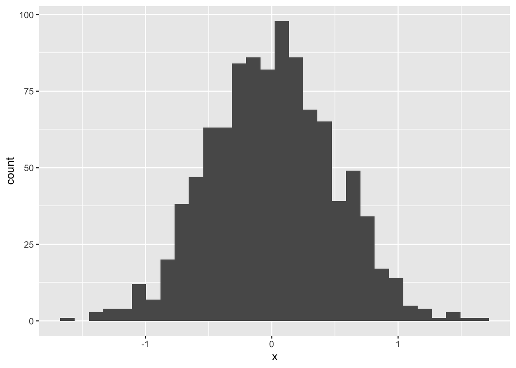

```r
ggplot(plot_df, aes(x=x)) + geom_histogram()
```

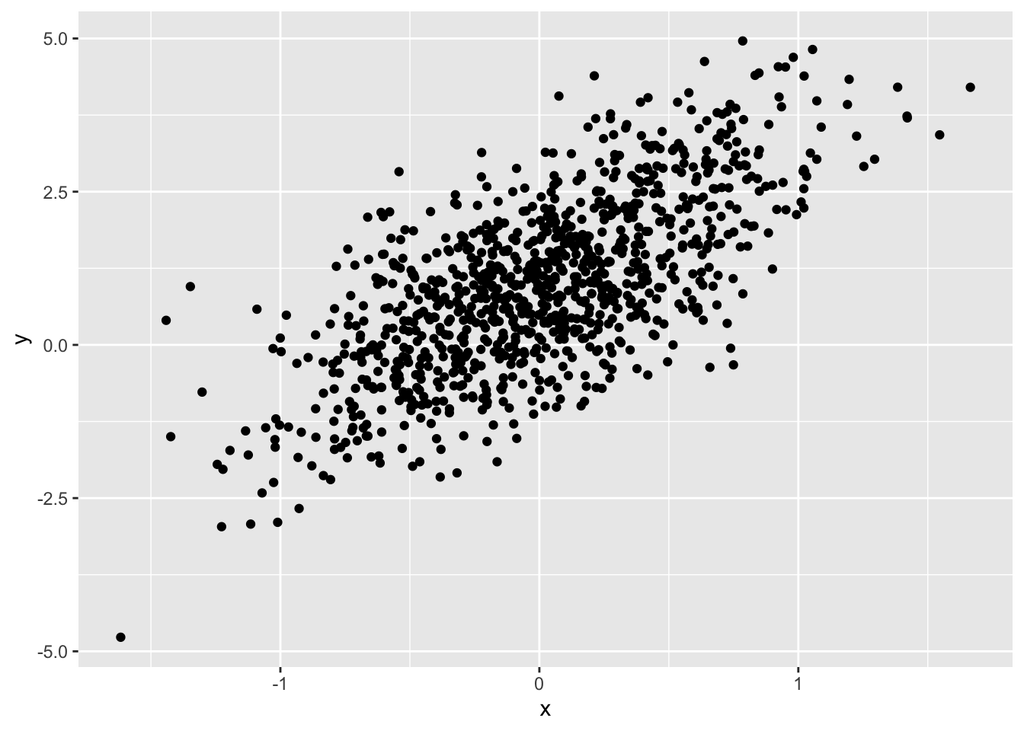

```r
ggplot(plot_df, aes(x=x, y=y)) + geom_point()
```

# Section 5

Write a named code chunk that creates a dataframe comprised of: a numeric variable containing a random sample of size 500 from a normal variable with mean 1; a logical vector indicating whether each sampled value is greater than zero; and a numeric vector containing the absolute value of each element. Then, produce a histogram of the absolute value variable just created. Add an inline summary giving the median value rounded to two decimal places. What happens if you set eval = FALSE to the code chunk? What about echo = FALSE?

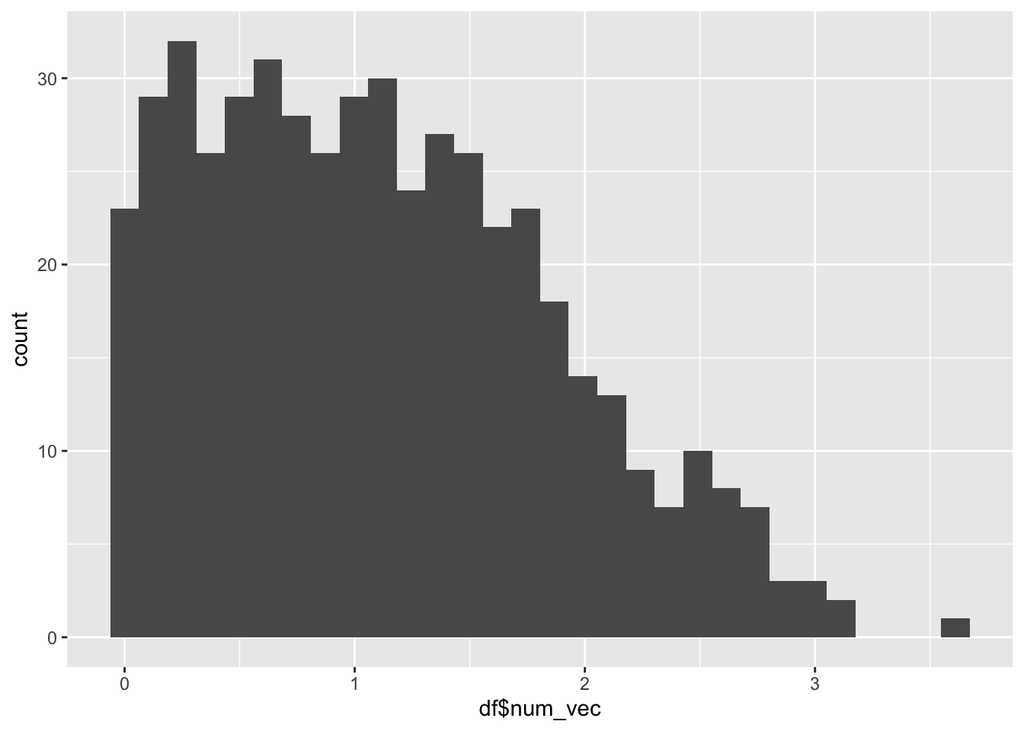

```r
df =
  tibble(
    num_var = rnorm(500, mean=1),
    log_vec = num_var > 0,
    num_vec = abs(num_var)
  )
#df$log_vec
ggplot(df, aes(x=df$num_vec)) + geom_histogram()
```

```r
#Using pull(df, num_vec) doesn't access location of variable, just values. $ does access storage.
```

The mediam is 1.05

# Section 6

This is **bold** or **bold** and this is *italic* or *italic*. This is `code` This is superscript<sup>2</sup> and subscript<sub>2</sub>

# Header 1

## Header 2

### Header 3

- Bullet Item *indented
1. Number list

## Table

| First | Second |
| --- | --- |
| Content | Content |

#Section 7

After the previous code chunk, write a bullet list given the mean, median, and standard deviation of the original random sample

- Here is the mean: 0.9547087
- Here is the median: 1.01
- Here is the stdv: 0.9624313

You can also use Latex here: $x = \frac{\Omega} {123}$